# hw_1

### Student Information

Name:余仲哲

Student ID:105071502

### Instructions

- Download the dataset provided in this [link](https://archive.ics.uci.edu/ml/datasets/Sentiment+Labelled+Sentences#). The sentiment dataset contains a `sentence` and `score` label. Read what the dataset is about on the link provided before you start exploring it.
- Then, you are asked to apply each of the data exploration and data operation techniques learned in the [first lab session](https://goo.gl/Sg4FS1) on the new dataset. You don't need to explain all the procedures as we did in the notebook, but you are expected to provide some **minimal comments** explaining your code. You are also expected to use the same libraries used in the first lab session. You are allowed to use and modify the `helper` functions we provided in the first lab session or create your own. Also, be aware that the helper functions may need modification as you are dealing with a completely different dataset. This part is worth 80% of your grade!
- After you have completed the operations, you should attempt the **bonus exercises** provided in the [notebook](https://goo.gl/Sg4FS1) we used for the first lab session. There are six (6) additional exercises; attempt them all, as it is part of your grade (10%).
- You are also expected to tidy up your notebook and attempt new data operations that you have learned so far in the Data Mining course. Surprise us! This segment is worth 10% of your grade.
- After completing all the above tasks, you are free to remove this header block and submit your assignment following the guide provided in the `README.md` file of the assignment's [repository](https://github.com/omarsar/data_mining_hw_1).

```python
# necessary for when working with external scripts
%load_ext autoreload
%autoreload 2
```

```
The autoreload extension is already loaded. To reload it, use:
  %reload_ext autoreload
```

```python
from plotly import __version__
from plotly.offline import download_plotlyjs, init_notebook_mode, plot, iplot

print (__version__) # requires version >= 1.9.0
import plotly.graph_objs as go
init_notebook_mode(connected=True)
# iplot([go.Scatter(x=[1, 2, 3], y=[3, 1, 6])])
```

```
2.2.3
```

```python
!pip3 install wordcloud
```

```
You are using pip version 9.0.1, however version 10.0.1 is available.
```

```python
import pandas as pd
import numpy as np
import nltk
from sklearn.datasets import fetch_20newsgroups
from sklearn.feature_extraction.text import CountVectorizer
import plotly.plotly as py
import plotly.graph_objs as go
import math
%matplotlib inline

# my functions
import helpers.data_mining_helpers as dmh
import helpers.text_analysis as ta
```

```python
categories = ['sentence','score']
```

```python
list_ = []
fileName = ['amazon_cells_labelled','imdb_labelled','yelp_labelled']
path = "./sentiment labelled sentences/";
frame = pd.DataFrame()
#read file into one dataframe
for n in fileName:
    df = pd.read_csv(path+n+".txt",sep="\\\t",names=categories,engine="python")
    list_.append(df)
```

### Exercise 0:

Experiment with other querying techniques using pandas dataframes. Refer to the their documentation for more information.

```python
#concatenate them and reassign the indexes
frame = pd.concat(list_).reset_index(drop=True)
len(frame)
```

```
3000
```

```python
len(list_)
```

```
3
```

```python
len(frame)
```

```
3000
```

```python
print(frame[::500])
```

```
                                               sentence  score
0     So there is no way for me to plug it in here i...      0
500   The bose noise cancelling is amazing, which is...      1
1000  A very, very, very slow-moving, aimless movie ...      0
1500  The entire audience applauded at the conclusio...      1
2000                           Wow... Loved this place.      1
2500  I also had to taste my Mom's multi-grain pumpk...      1
```

```python
#generate a record with missing value and append it
dummy_series = pd.Series([None,None], index=["sentence", "score"])
```

```python
dummy_series
```

```
sentence    None
score       None
dtype: object
```

```python
result_with_series = frame.append(dummy_series, ignore_index=True)
```

```python
len(result_with_series)
```

```
3001
```

```python
#cal how many missing value in each column
result_with_series.isnull().apply(lambda x: dmh.check_missing_values(x))
```

```
sentence    (The amoung of missing records is: , 1)
score       (The amoung of missing records is: , 1)
dtype: object
```

### Exercise 1:

Code for how to calculate the missing values for every record instead of every column. Hint axis parameter. Check the documentation for more information.

```python
result_with_series.isnull().apply(lambda x: dmh.check_missing_values(x), axis=1)
```

```
0       (The amoung of missing records is: , 0)
1       (The amoung of missing records is: , 0)
2       (The amoung of missing records is: , 0)
3       (The amoung of missing records is: , 0)
4       (The amoung of missing records is: , 0)
5       (The amoung of missing records is: , 0)
6       (The amoung of missing records is: , 0)
7       (The amoung of missing records is: , 0)
8       (The amoung of missing records is: , 0)
9       (The amoung of missing records is: , 0)
10      (The amoung of missing records is: , 0)
11      (The amoung of missing records is: , 0)
12      (The amoung of missing records is: , 0)
13      (The amoung of missing records is: , 0)
14      (The amoung of missing records is: , 0)
```

[output cut: 47 more lines]

```python
#according to the dmh file, programmer can transpose the dataframe before calculate the amounts of missing value
#then i would get how many missing value in each record
result_with_series.transpose().isnull().apply(lambda x: dmh.check_missing_values(x))
```

```
0       (The amoung of missing records is: , 0)
1       (The amoung of missing records is: , 0)
2       (The amoung of missing records is: , 0)
3       (The amoung of missing records is: , 0)
4       (The amoung of missing records is: , 0)
5       (The amoung of missing records is: , 0)
6       (The amoung of missing records is: , 0)
7       (The amoung of missing records is: , 0)
8       (The amoung of missing records is: , 0)
9       (The amoung of missing records is: , 0)
10      (The amoung of missing records is: , 0)
11      (The amoung of missing records is: , 0)
12      (The amoung of missing records is: , 0)
13      (The amoung of missing records is: , 0)
14      (The amoung of missing records is: , 0)
```

[output cut: 47 more lines]

Actually I don't know the question is asking how many missing value in a record or show that each record is cotainning any missing value so i completed it in both ways.

```python
result_with_series.isnull().any(axis=1)
```

```
0       False
1       False
2       False
3       False
4       False
5       False
6       False
7       False
8       False
9       False
10      False
11      False
12      False
13      False
14      False
```

[output cut: 47 more lines]

Number of record containning missing value

```python
result_with_series.shape[0] - result_with_series.dropna().shape[0]
```

```
1
```

```python
result_with_series.dropna(inplace=True)
```

```python
result_with_series.isnull().apply(lambda x: dmh.check_missing_values(x))
```

```
sentence    (The amoung of missing records is: , 0)
score       (The amoung of missing records is: , 0)
dtype: object
```

```python
#after dropna, result_with_series deleted the last record, and length became 3000 again
len(result_with_series)
```

```
3000
```

```python
frame.isnull().apply(lambda x: dmh.check_missing_values(x))
```

```
sentence    (The amoung of missing records is: , 0)
score       (The amoung of missing records is: , 0)
dtype: object
```

```python
sum(frame.duplicated())
```

```
17
```

```python
X = frame
```

```python
sum(X.duplicated())
```

```
17
```

```python
#keep the first recode if there is a duplicate one
X.drop_duplicates(keep='first', inplace=True)
```

```python
len(frame)
```

```
2983
```

```python
len(X)
```

```
2983
```

```python
X_sample = X.sample(n=1000)
```

```python
len(X_sample)
```

```
1000
```

```python
categories
```

```
['sentence', 'score']
```

```python
X_category_counts = ta.get_tokens_and_frequency(X.score)
X_sample_category_counts = ta.get_tokens_and_frequency(X_sample.score)
```

```python
iplot(ta.plot_word_frequency(X_category_counts, "Category distribution"))
```

[interactive chart not shown]

```python
iplot(ta.plot_word_frequency(X_sample_category_counts, "Category distribution"))
```

[interactive chart not shown]

### Exercise 2:

We can also do a side by side comparison of the distribution between the two datasets, but maybe you can try that as an excerise. Look at the Plotly documents for tons of examples and ways to visualizing groups bar charts.

```python
trace1 = go.Bar(
    x=list(X_category_counts[0]),
    y=list(X_category_counts[1]),
    name='X'
)
trace2 = go.Bar(
    x=list(X_sample_category_counts[0]),
    y=list(X_sample_category_counts[1]),
    name='X_sample'
)

data = [trace1, trace2]
layout = go.Layout(
    barmode='group'
)

fig = go.Figure(data=data, layout=layout)
iplot(fig, filename='grouped-bar')
```

[interactive chart not shown]

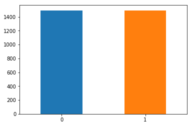

```python
X.score.value_counts().plot(kind="bar", rot=0)
```

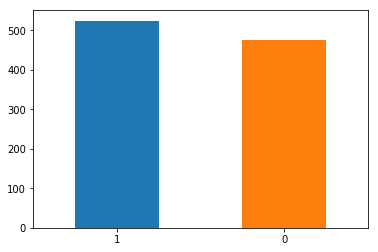

```python
X_sample.score.value_counts().plot(kind="bar", rot=0)
```

```python
# takes a like a minute or two to process
X['unigrams'] = X['sentence'].apply(lambda x: dmh.tokenize_text(x))
```

```python
#tokenize the sentence
X['unigrams'][0:10]
```

```
0    [So, there, is, no, way, for, me, to, plug, it...
1                 [Good, case, ,, Excellent, value, .]
2                        [Great, for, the, jawbone, .]
3    [Tied, to, charger, for, conversations, lastin...
4                             [The, mic, is, great, .]
5    [I, have, to, jiggle, the, plug, to, get, it, ...
6    [If, you, have, several, dozen, or, several, h...
7    [If, you, are, Razr, owner, ..., you, must, ha...
8      [Needless, to, say, ,, I, wasted, my, money, .]
9         [What, a, waste, of, money, and, time, !, .]
Name: unigrams, dtype: object
```

```python
list(X[0:2]['unigrams'])
```

```
[['So',
  'there',
  'is',
  'no',
  'way',
  'for',
  'me',
  'to',
  'plug',
  'it',
  'in',
  'here',
  'in',
  'the',
  'US',
  'unless',
  'I',
  'go',
  'by',
  'a',
  'converter',
  '.'],
 ['Good', 'case', ',', 'Excellent', 'value', '.']]
```

```python
X['unigrams'].head()
```

```
0    [So, there, is, no, way, for, me, to, plug, it...
1                 [Good, case, ,, Excellent, value, .]
2                        [Great, for, the, jawbone, .]
3    [Tied, to, charger, for, conversations, lastin...
4                             [The, mic, is, great, .]
Name: unigrams, dtype: object
```

```python
count_vect = CountVectorizer()
X_counts = count_vect.fit_transform(X.sentence)
```

```python
X_counts.shape
```

```
(2983, 5155)
```

```python
count_vect.get_feature_names()[0:10]
```

```
['00', '10', '100', '11', '12', '13', '15', '15g', '15pm', '17']
```

```python
X[0:5]
```

|  | sentence | score | unigrams |
| --- | --- | --- | --- |
| 0 | So there is no way for me to plug it in here i... | 0 | [So, there, is, no, way, for, me, to, plug, it... |
| 1 | Good case, Excellent value. | 1 | [Good, case, ,, Excellent, value, .] |
| 2 | Great for the jawbone. | 1 | [Great, for, the, jawbone, .] |
| 3 | Tied to charger for conversations lasting more... | 0 | [Tied, to, charger, for, conversations, lastin... |
| 4 | The mic is great. | 1 | [The, mic, is, great, .] |

```python
X_counts
```

```
<2983x5155 sparse matrix of type '<class 'numpy.int64'>'
	with 31515 stored elements in Compressed Sparse Row format>
```

```python
X_counts[0:5].toarray()
```

```
array([[0, 0, 0, ..., 0, 0, 0],
       [0, 0, 0, ..., 0, 0, 0],
       [0, 0, 0, ..., 0, 0, 0],
       [0, 0, 0, ..., 0, 0, 0],
       [0, 0, 0, ..., 0, 0, 0]], dtype=int64)
```

```python
print(X_counts[0]>0)
```

```
  (0, 647)	True
  (0, 1013)	True
  (0, 1829)	True
  (0, 1982)	True
  (0, 2158)	True
  (0, 2314)	True
  (0, 2427)	True
  (0, 2432)	True
  (0, 2809)	True
  (0, 3043)	True
  (0, 3387)	True
  (0, 4161)	True
  (0, 4531)	True
  (0, 4545)	True
  (0, 4609)	True
  (0, 4793)	True
  (0, 4835)	True
  (0, 4987)	True
```

```python
count_vect.transform(['Something completely new.'])
```

```
<1x5155 sparse matrix of type '<class 'numpy.int64'>'
	with 3 stored elements in Compressed Sparse Row format>
```

```python
count_vect.transform(['00 Something completely new.']).toarray()
```

```
array([[1, 0, 0, ..., 0, 0, 0]], dtype=int64)
```

```python
plot_x = ["term_"+str(i) for i in count_vect.get_feature_names()[0:20]]
```

```python
plot_x
```

```
['term_00',
 'term_10',
 'term_100',
 'term_11',
 'term_12',
 'term_13',
 'term_15',
 'term_15g',
 'term_15pm',
 'term_17',
 'term_18',
 'term_18th',
 'term_1928',
 'term_1947',
 'term_1948',
 'term_1949',
 'term_1971',
 'term_1973',
 'term_1979',
 'term_1980']
```

```python
plot_y = ["doc_"+ str(i) for i in list(X.index)[0:20]]
```

```python
plot_z = X_counts[0:20, 0:20].toarray()
```

```python
# to plot
iplot(ta.plot_heat_map(plot_x, plot_y, plot_z))
```

[interactive chart not shown]

### Exercise 3:

From the chart above, we can see how sparse the term-document matrix is; i.e., there is only one terms with frequency of 1 in the subselection of the matrix. By the way, you may have noticed that we only selected 20 articles and 20 terms to plot the histrogram. As an excersise you can try to modify the code above to plot the entire term-document matrix or just a sample of it.

```python
plot_x = ["term_"+str(i) for i in count_vect.get_feature_names()[:500]]
plot_y = ["doc_"+ str(i) for i in list(X.index)[:500]]
plot_z = X_counts[:500,:500].toarray()
iplot(ta.plot_heat_map(plot_x, plot_y, plot_z))
```

[interactive chart not shown]

### 5.4 Dimensionality Reduction

```python
from sklearn.decomposition import PCA
```

```python
X_reduced = PCA(n_components=3).fit_transform(X_counts.toarray())
```

```python
X_reduced.shape
```

```
(2983, 3)
```

```python
X_reduced
```

```
array([[ 0.524039  ,  0.28723255, -1.33344116],
       [-0.89836917, -0.36059226,  0.22779087],
       [ 0.01536216, -0.66715455,  0.09300661],
       ...,
       [-0.50167697,  0.4133818 ,  0.69508277],
       [ 0.49819502,  0.36755774,  0.35569775],
       [ 2.33191552, -0.47565889, -1.1506818 ]])
```

```python
categories
```

```
['sentence', 'score']
```

```python
trace1 = ta.get_trace(X_reduced, X["score"], 0, "rgb(71,233,163)")
trace2 = ta.get_trace(X_reduced, X["score"], 1, "rgb(52,133,252)")
```

```python
data = [trace1, trace2]
```

```python
layout = go.Layout(
    margin=dict(
        l=0,
        r=0,
        b=0,
        t=0
    )
)
fig = go.Figure(data=data, layout=layout)
iplot(fig, filename='simple-3d-scatter')
```

[interactive chart not shown]

### 5.5 Atrribute Transformation / Aggregation

```python
X_counts.shape
```

```
(2983, 5155)
```

## sum(X_counts[:,j].toarray()) >> sum(X_counts[:,j])

```python
# note this takes time to compute. You may want to reduce the amount of terms you want to compute frequencies for
term_frequencies = []
for j in range(0,X_counts.shape[1]):
    term_frequencies.append(sum(X_counts[:,j].toarray()))
```

```python
print(term_frequencies[:3])
```

```
[array([1], dtype=int64), array([36], dtype=int64), array([3], dtype=int64)]
```

```python
term_frequencies = [i[0] for i in term_frequencies]
print(term_frequencies[:3])
```

```
[1, 36, 3]
```

```python
iplot(ta.plot_word_frequency([count_vect.get_feature_names(), term_frequencies], "Term Frequency Distribution"))
```

[interactive chart not shown]

### Exercise 4:

The chart above contains all the vocabulary, and it's computationally intensive to both compute and visualize. You can try to reduce the number of terms you want to visualize as an exercise.

```python
iplot(ta.plot_word_frequency([count_vect.get_feature_names()[::1000], term_frequencies[::1000]], "Term Frequency Distribution"))
```

[interactive chart not shown]

### Exercise 5:

Additionally, you can attempt to sort the terms on the x-axis by frequency instead of in alphabetical order.

```python
tmpList= count_vect.get_feature_names()
tmpFreq = term_frequencies
tmpFreq, tmpList = zip(*sorted(zip(tmpFreq, tmpList), reverse=True))

#draw
iplot(ta.plot_word_frequency([tmpList[:100], tmpFreq[:100]], "Term Frequency Distribution"))
```

[interactive chart not shown]

```python
term_frequencies_log = [math.log(i) for i in term_frequencies]
iplot(ta.plot_word_frequency([count_vect.get_feature_names(), term_frequencies_log], "Term Frequency Distribution"))
```

[interactive chart not shown]

```python
iplot(ta.plot_word_frequency([count_vect.get_feature_names(), term_frequencies], "Term Frequency Distribution"))
```

[interactive chart not shown]

```python
from sklearn import preprocessing, metrics, decomposition, pipeline, dummy
```

```python
mlb = preprocessing.LabelBinarizer()
```

```python
mlb.fit(X.score)
X.score[:10]
```

```
0    0
1    1
2    1
3    0
4    1
5    0
6    0
7    1
8    0
9    0
Name: score, dtype: int64
```

```python
mlb.classes_
```

```
array([0, 1], dtype=int64)
```

```python
X['bin_category'] = mlb.transform(X.score).tolist()
```

```python
X[0:9]
```

|  | sentence | score | unigrams | bin_category |
| --- | --- | --- | --- | --- |
| 0 | So there is no way for me to plug it in here i... | 0 | [So, there, is, no, way, for, me, to, plug, it... | [0] |
| 1 | Good case, Excellent value. | 1 | [Good, case, ,, Excellent, value, .] | [1] |
| 2 | Great for the jawbone. | 1 | [Great, for, the, jawbone, .] | [1] |
| 3 | Tied to charger for conversations lasting more... | 0 | [Tied, to, charger, for, conversations, lastin... | [0] |
| 4 | The mic is great. | 1 | [The, mic, is, great, .] | [1] |
| 5 | I have to jiggle the plug to get it to line up... | 0 | [I, have, to, jiggle, the, plug, to, get, it, ... | [0] |
| 6 | If you have several dozen or several hundred c... | 0 | [If, you, have, several, dozen, or, several, h... | [0] |
| 7 | If you are Razr owner...you must have this! | 1 | [If, you, are, Razr, owner, ..., you, must, ha... | [1] |
| 8 | Needless to say, I wasted my money. | 0 | [Needless, to, say, ,, I, wasted, my, money, .] | [0] |

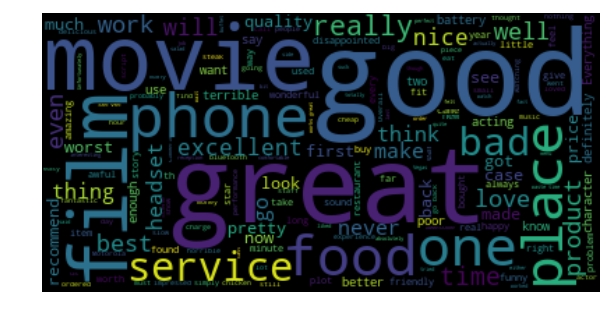

```python
ta.plot_word_cloud(X.sentence.to_string())
```